# SCocke_HW3

Steven Cocke

May 28, 2018

## Question 1:

### Using Git, clone the following GitHub repository to your local machine: https://github.com/caesar0301/awesome-public-datasets. In RMarkdown, please show the code (commented out, as it’s not R syntax) that you used to create a new directory, navigate to the appropriate directory, and clone the repository to it. Like actual Git, one command per line, please.

#### Stevens-MacBook-Pro:~ stevencocke$ cd Desktop

#### Stevens-MacBook-Pro:Desktop stevencocke$ mkdir MSDS6306

#### Stevens-MacBook-Pro:Desktop stevencocke$ cd MSDS6306/

#### Stevens-MacBook-Pro:MSDS6306 stevencocke$ git clone ####https://github.com/awesomedata/awesome-public-datasets.git

#### Cloning into ‘awesome-public-datasets’…

#### remote: Counting objects: 1475, done.

#### remote: Total 1475 (delta 0), reused 0 (delta 0), pack-reused 1475

#### Receiving objects: 100% (1475/1475), 561.47 KiB | 8.64 MiB/s, done.

#### Resolving deltas: 100% (860/860), done.

#### Stevens-MacBook-Pro:MSDS6306 stevencocke$ ls

## Question 2

### a. In R, please read in titanic.csv via either read.table() or read.csv(), assigning it to df. This dataset follows the passengers aboard the Titanic, including their fees paid, rooms rented, and survivorship status.

```r
##This reads in the data
titanicdata <- read.csv(file="/Users/stevencocke/Desktop/MSDS6306/awesome-public-datasets/Datasets/titanic.csv", header=TRUE, sep=",")
```

### b. Output the respective count of females and males aboard the Titanic. Plot the frequency of females and males. Be sure to give an accurate title and label the axes.

```r
##This gathers the counts of male and female passengers
length(which(titanicdata$Sex == 'male'))
```

```
## [1] 577
```

```r
length(which(titanicdata$Sex == 'female'))
```

```
## [1] 314
```

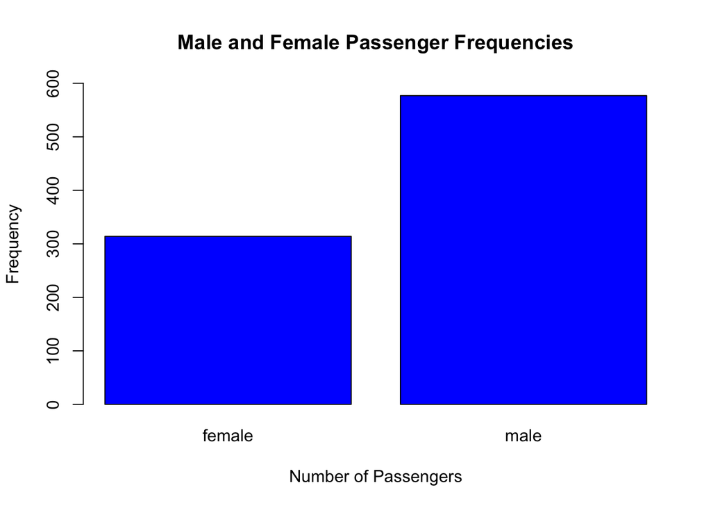

```r
##This puts the Sex data in a table
totals <- table(titanicdata$Sex)
##This creates a barplot
barplot(totals, main="Male and Female Passenger Frequencies",
        xlab="Number of Passengers", ylab="Frequency", col="Blue", ylim=c(0, 600))
```

### c. Please use one apply function (to review: swirl() modules 11, 12) to output the means of Age, Fare, and Survival. Make sure the output is a real number for all three means.

```r
##This grabs the Age, Fare, and Survival columns
Means <- titanicdata[, c(2,6,10)]

##This applys the mean function to the columns and ignores the NA values
sapply(Means, mean, na.rm=TRUE)
```

```
##   Survived        Age       Fare
##  0.3838384 29.6991176 32.2042080
```

## Question 3

```r
##read in the data
sleepdata <- read.csv(file="/Users/stevencocke/Desktop/MSDS6306/sleep_data_01.csv", header=TRUE, sep=",")
```

### a. Create objects for the median Age, the minimum and maximum Duration of sleep, and the mean and standard deviation of the Rosenberg Self Esteem scale (RSES). You may need to specify a few options like in Problem 2 and live session.

### b. Create a data.frame object called report: it should consist of the median age, the RSES mean and standard deviation respectively divided by five (since there are five questions and these scores are summed), and the range of Duration (the statistical definition of range; it should be a single number.)

### c. Change the column names of this data.frame to MedianAge, SelfEsteem, SE_SD, and DurationRange.

### d. Round the report to at most 2 digits: leave this as the closing line to the function.

### e. Finally, run the function on your sleep data to show the output.

```r
##read in the data
sleepdata <- read.csv(file="/Users/stevencocke/Desktop/MSDS6306/sleep_data_01.csv", header=TRUE, sep=",")

##this is a function
sleepdatafunction <- function(dataframe) {
  ##computes the median of the Age variable, ignores NAs, and stores the result
  medAge <- median(sleepdata$Age, na.rm = TRUE)
  ##computes the min and max of the Duration variable, ignores NAs, and stores the result
  sleepduration <- c(min(sleepdata$Duration, na.rm=TRUE), max(sleepdata$Duration, na.rm=TRUE))
  ##computes the mean and standard deviation of the RSES variable, ignores NAs, and stores the result
  RSES <- RSES <- c(mean(sleepdata$RSES, na.rm = TRUE), sd(sleepdata$RSES, na.rm = TRUE))
  ##creates new column names for the final report and stores them
  reportnames <- c("MedianAge", "SelfEsteem", "SE_SD", "DurationRange")
  ##creates the report data frame with the results desired
  report <- data.frame(medAge, RSES[1]/5, RSES[2]/5, sleepduration[2]-sleepduration[1])
  ##changes the column names
  names(report) <- reportnames
  ##rounds the report to have at most 2 digits
  round_report <- round(report, digits=2)
  ##returns the final report
  return(round_report)
}
##runs the created function
sleepdatafunction(sleepdata)
```

```
##   MedianAge SelfEsteem SE_SD DurationRange
## 1        14       3.62  1.24             7
```